# ggplot challenge

jrm

Can you recreate the plots below?

I created them using the datasets included by default and ggplot only. I didn’t do any transformations of any kind or installed extra packages. I am also not providing the code ;)

For each plot I am just including the dataset and maybe some clues. Try to replicate them, use your imagination and remember, google (or [duckduckgo](https://duckduckgo.com) if you value your privacy) is your best friend!.

```r
library(tidyverse)
```

### Flippin’ boxplots

Here I’m using the `diamonds` dataset. Note that the orientation of the boxplots is *flipped* along the x-axis. The names in the color *guide* are reversed to match their order in the plot.

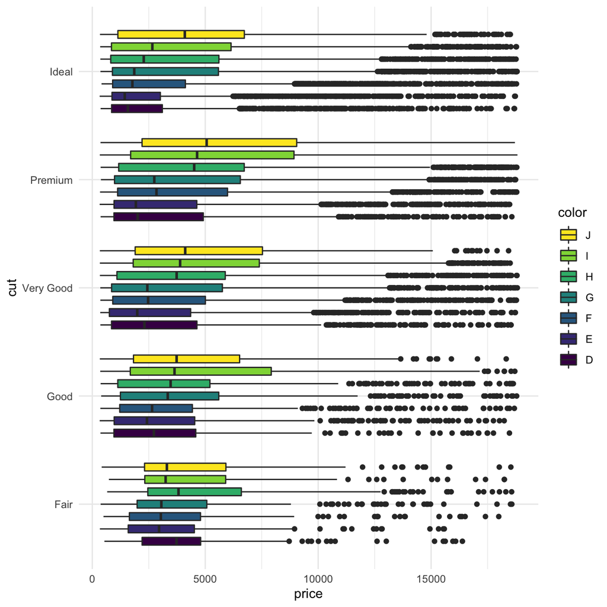

### Rugged plot

`mpg` dataset. I am *manually* setting the color *scale* to “skyblue”, “salmon”, and “purple” over a *dark* theme.

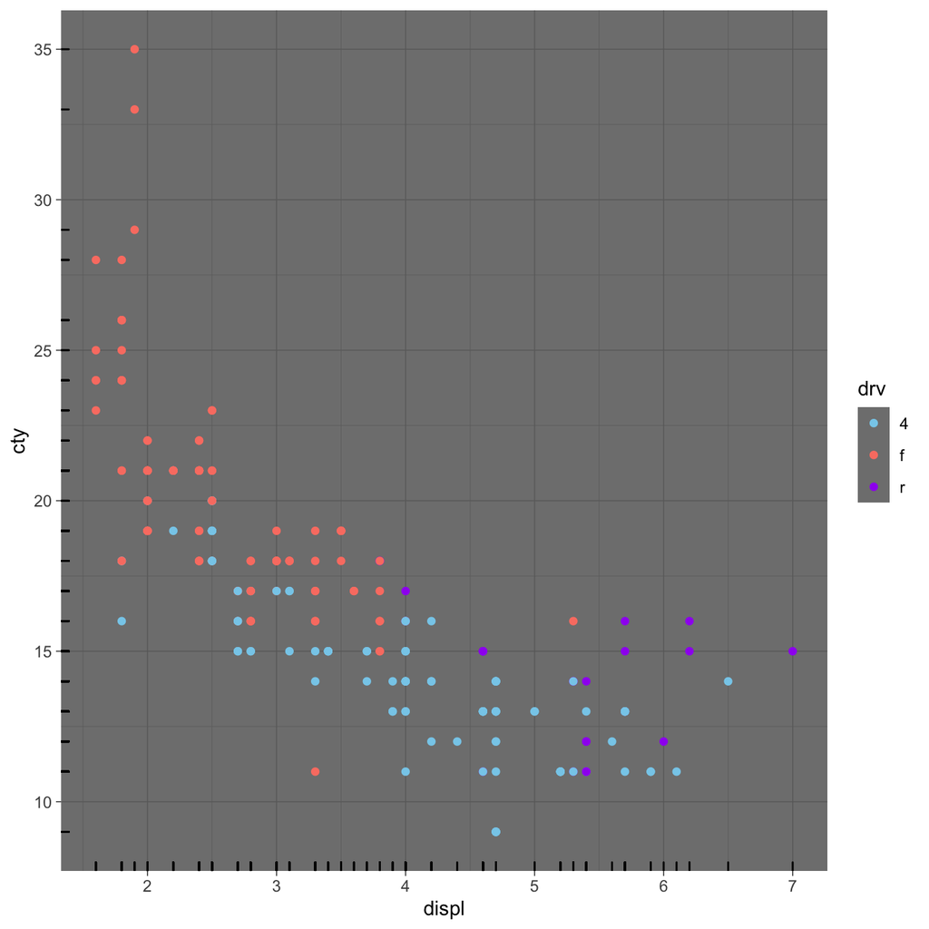

### 2dense 2plot

`mpg` dataset again. Check `density2d` to see how I created the orange lines around the plot. The points have some noise added so they won’t overlap. Notice that the plot only shows the bottom and left lines (ie, no grids or full frame).

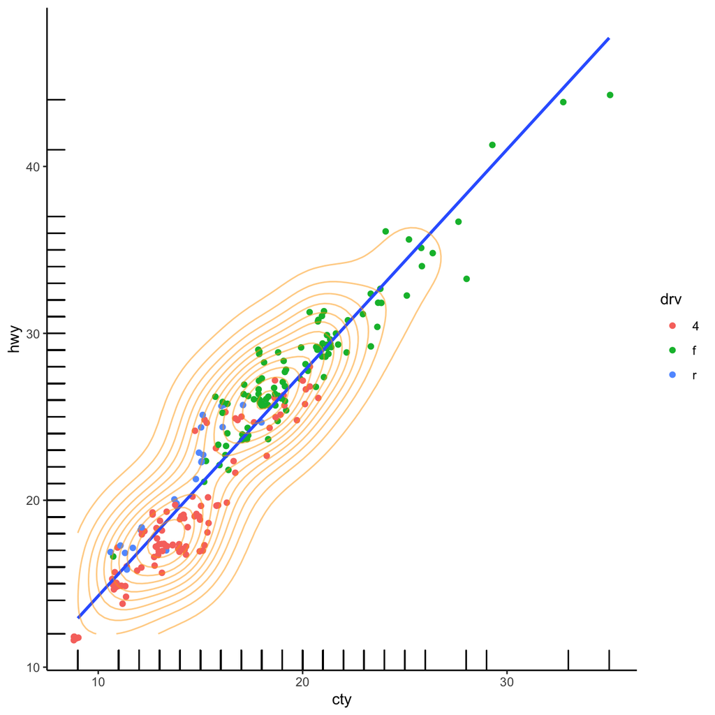

### oh beehive!

The relationship between carat and price in the `diamonds` *binned* into 15 groups. The *gradient* color scale uses “skyblue” as the *low* point and “yellow” as the *high*.

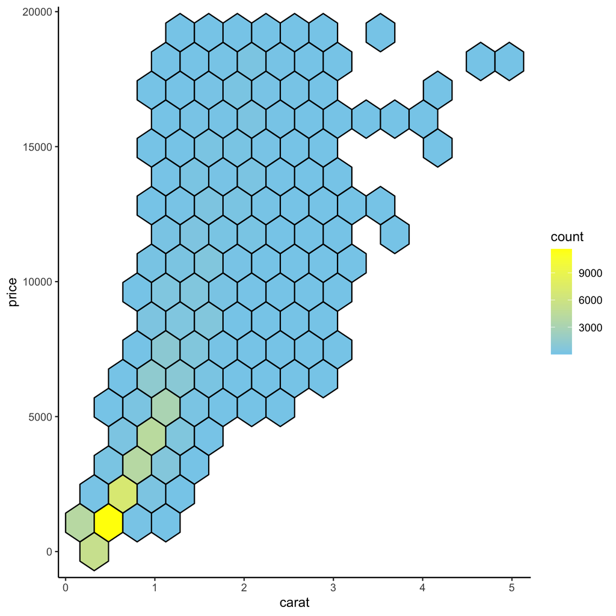

### regress me maybe

Using the `iris` data set, look at the relationship between sepal length and petal length and look for a trend (ie, a **l**inear **m**odeling approach). Is there a difference between the 3 species? Notice that the points and colors are different for each species. The *grid* has been *faceted* by species. Note how the scales vary *free*ly along the *y* axis.

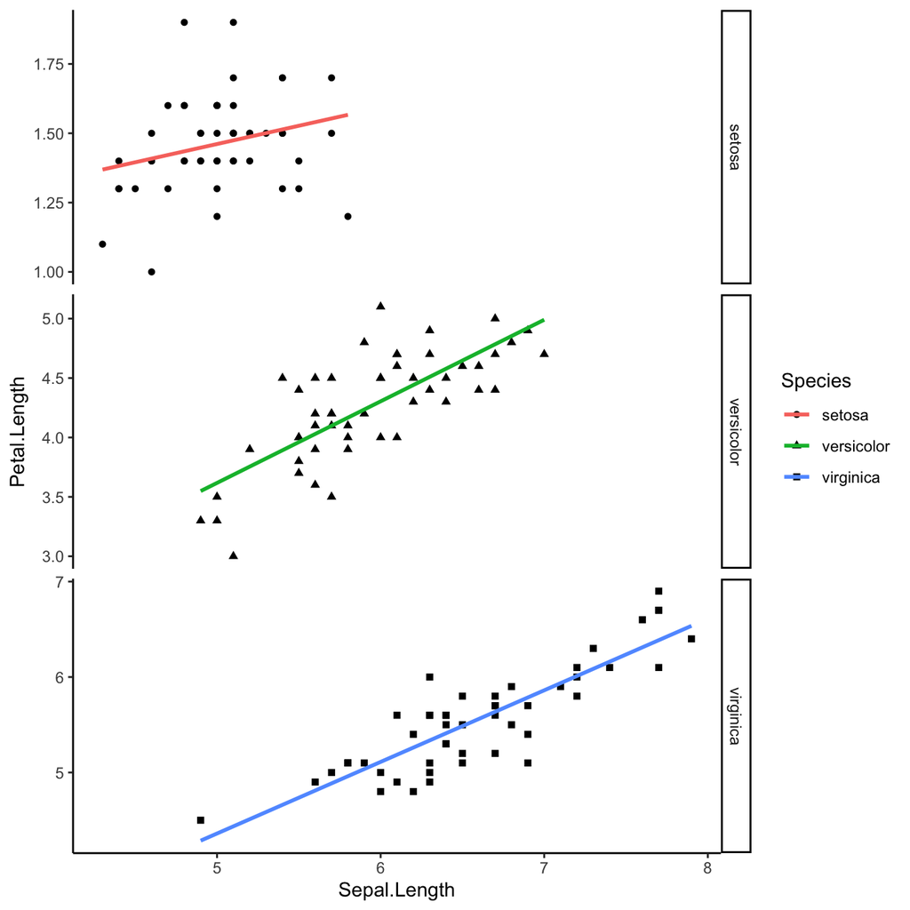